# Merge Sort

### Divide

Proses Splitting atau Divide adalah proses yang membagi list data menjadi dua buah bagian. Proses splitting data list ini dilakukan secara terus menerus, sampai hanya tersisa satu elemen saja didalam list. Top-Down Process Contoh proses ini dapat dilihat pada Gambar 1 berikut :

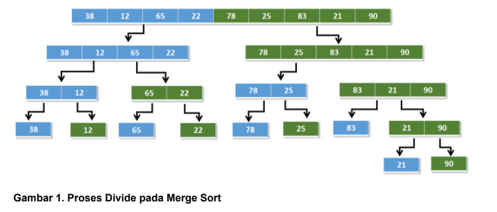

Pada Gambar 1 tersebut ditunjukkan bahwa data yang terdiri dari sembilan elemen, yaitu [38, 12, 65, 22, 78, 25, 83, 21, 90]. Pada proses divide ini, data dibagi menjadi dua bagian kiri (warna biru) dan kanan (warna hijau), sehingga data bagian kiri terdiri dari empat elemen, yaitu [38, 12, 65, 22], sedangkan bagian kanan menjadi [78, 25, 83, 21, 90]. Proses ini dilakukan terus menerus, sehingga terdapat data yang hanya memiliki satu elemen saja, yaitu [38], [12], [65], [22], [78], [25], [83], [21], dan [90].  
Berikut algoritma untuk membagi data menjadi dua bagian, kiri dan kanan.  
mid = len(data) // 2  
leftData = data[:mid]  
rightData = data[mid:]

### Merge

Proses Merge ini menggabungkan data-data yang sudah terbagi pada Tahap pertama (divide/split). Proses merge ini juga melibatkan proses membandingkan data antara list yang akan digabung. Sehingga, setelah proses merge, data pada list akan terurut. Proses ini akan dilakukan terus menerus, sehingga tidak ada lagi list yang akan digabungkan. Tahapan merge ini adalah Bottom - up process Contoh proses merge dapat dilihat pada Gambar 2 berikut

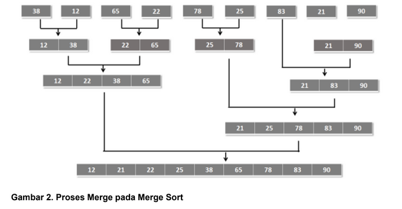

Pada Gambar tersebut ditunjukka, pada proses merging, data yang terdapat pada list yang akan digabung, dibandingkan terlebih dahulu, jika data lebih kecil, maka data tersebut akan diletakkan pada indeks yang lebih rendah, sehingga setelah proses merging selesai, data sudah dalam keadaan terurut.

### Code

```python
def merge_sort(a_list):
    print("Splitting ", a_list)
    if len(a_list) > 1:
        mid = len(a_list) // 2
        left_half = a_list[:mid]
        right_half = a_list[mid:]
        merge_sort(left_half)
        merge_sort(right_half)
        i = 0 #indeks left half
        j = 0 #indeks right half
        k = 0 # indeks hasil merging/sorting
        while i < len(left_half) and j < len(right_half):
            if left_half[i] < right_half[j]:
                a_list[k] = left_half[i]
                i = i + 1
            else:
                a_list[k] = right_half[j]
                j = j + 1
            k = k + 1
        while i < len(left_half):
            a_list[k] = left_half[i]
            i = i + 1
            k = k + 1
        while j < len(right_half):
            a_list[k] = right_half[j]
            j = j + 1
            k = k + 1
    print("Merging ", a_list)
```

```python
a = [38,12,65,22,78,25,83,21,90]
merge_sort(a)
```

```
Splitting  [38, 12, 65, 22, 78, 25, 83, 21, 90]
Splitting  [38, 12, 65, 22]
Splitting  [38, 12]
Splitting  [38]
Merging  [38]
Splitting  [12]
Merging  [12]
Merging  [12, 38]
Splitting  [65, 22]
Splitting  [65]
Merging  [65]
Splitting  [22]
Merging  [22]
Merging  [22, 65]
Merging  [12, 22, 38, 65]
Splitting  [78, 25, 83, 21, 90]
Splitting  [78, 25]
Splitting  [78]
Merging  [78]
Splitting  [25]
Merging  [25]
Merging  [25, 78]
Splitting  [83, 21, 90]
Splitting  [83]
Merging  [83]
Splitting  [21, 90]
Splitting  [21]
Merging  [21]
Splitting  [90]
Merging  [90]
Merging  [21, 90]
Merging  [21, 83, 90]
Merging  [21, 25, 78, 83, 90]
Merging  [12, 21, 22, 25, 38, 65, 78, 83, 90]
```

# Quick Sort

Berbeda dengan algoritma merge sort yang membagi data menjadi dua bagian, tanpa syarat apapun, maka pada algoritma quick sort ini, pembagian data menjadi dua buah bagian, harus memenuhi ketentuan bahwa, data yang berada di bagian sebelah kiri (bagian data pertama), haruslah data-data yang memiliki nilai lebih kecil dari nilai pivot (tidak harus urut). Sedangkan, data-data yang berada disebelah kanan (bagian data kedua), adalah data-data yang memiliki nilai lebih besar dari nilai pivot, seperti yang terlihat pada Gambar 1.

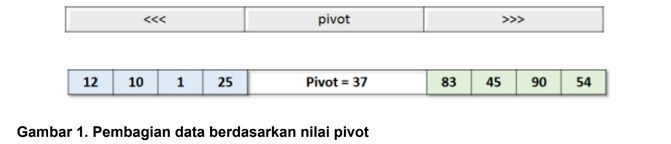

Gambar 1 menunjukkan contoh data yang terbagi berdasarkan nilai pivot. Misalkan nilai pivot=37, maka data yang terdapat pada sebelah kiri pivot, memiliki nilai lebih kecil dari pada pivot, yaitu [12, 10, 1, 25], sedangkan data-data yang berada di sebelah kanan pivot, memiliki nilai lebih besar dari pada pivot, yaitu [83, 45, 90, 54].  
Algoritma untuk membagi data atau partisi data menjadi dua bagian berdasarkan nilai pivot tersebut adalah sebagai berikut :  
partisi(A,p,q) # A=data ; p=indeks awal data yang akan dipartisi, q=inde ks akhir data yang akan dipartisi  
1. x=A[p] #pivot=x=a[p]  
2. i=p  
3. for j in range(p+1, q+1) :  
4. if A[j]<=x:  
5. i=i+1  
6. A[i],A[j]=A[j],A[i]  
7. A[p],A[i]=A[i],A[p]  
Pada algoritma tersebut, nilai pivot merupakan data yang terdapat pada indeks awal dari data yang akan dipartisi, misalkan 0. Baris pertama menunjukkan bawa data pivot disimpan dalam variabel . Untuk mencari data-data yang bernilai kurang dari pivot, maka dilakukan penelusuran, mulai dari data setelah indeks pivot, sampai dengan data terakhir yang akan dipartisi. Pada proses tersebut, pencarian direpresentasikan dengan variabel , lihat baris ketiga. Setelah didapatkan data yang memiliki nilai lebih kecil dari pivot, maka data tersebut ditukar dengan data yang terdapat pada data disebelah pivot, lihat baris kelima dan keenam. Posisi data terakhir yang memiliki nilai lebih kecil dari data pivot, disimpan dalam variabel i, sehingga pada baris ketujuh, dilakukan pertukaran dengan data tersebut dengan data pivot (lihat baris ketujuh)  
Ilustrasi partisi ini dapat dilihat pada Gambar 2.

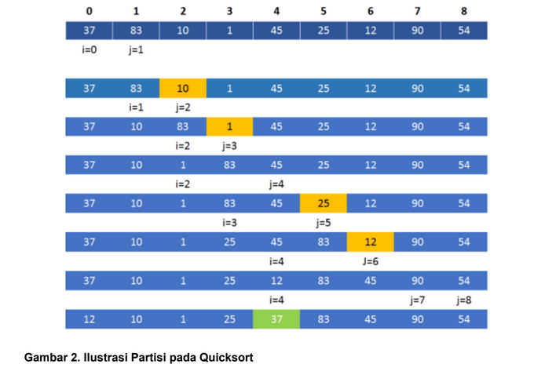

### Code

```python
def partition (A,p,q):
    x=A[p] #pivot=x=a[p]
    i=p
    for j in range(p+1, q+1) :
        if A[j]<=x:
            i=i+1
            A[i],A[j]=A[j],A[i]
        print(A)
    A[p],A[i]=A[i],A[p]
    return i
```

```python
a=[37,83,10,1,45,25,12,90,54]
partition(a,0,len(a)-1)
print(a)
```

```
[37, 83, 10, 1, 45, 25, 12, 90, 54]
[37, 10, 83, 1, 45, 25, 12, 90, 54]
[37, 10, 1, 83, 45, 25, 12, 90, 54]
[37, 10, 1, 83, 45, 25, 12, 90, 54]
[37, 10, 1, 25, 45, 83, 12, 90, 54]
[37, 10, 1, 25, 12, 83, 45, 90, 54]
[37, 10, 1, 25, 12, 83, 45, 90, 54]
[37, 10, 1, 25, 12, 83, 45, 90, 54]
[12, 10, 1, 25, 37, 83, 45, 90, 54]
```

### Combine

Tahap kedua pada algoritma quicsort adalah tahapan combine. Pada tahapan ini, hanya memerintahkan partisi yang berulang kali. Data yang sudah dipartisi, akan terdiri dari dua bagian data, yaitu bagian pertama dan kedua. Bagian pertama dilakukan partisi lagi, menjadi dua buah bagian, begitu juga bagian kedua, begitu seterusnya, sampai tidak ada data lagi yang akan dipartisi. Sehingga hasil akhir adalah, data akan terurut.  
Pada contoh Gambar 2 tersebut, nilai pivot berada pada indeks ke-4. Nilai pivot di akhir proses partisi, menempati indeks yang sebenarnya, ketika data tersebut dalam keadaan terurut. Sehingga proses partisi akan dilakukan pada data-data sebelum nilai pivot, dan data setelah nilai pivot.  
Proses combine yang dilakukan dengan cara memerintahkan partisi berulang, seperti yang terlihat pada Gambar 3.

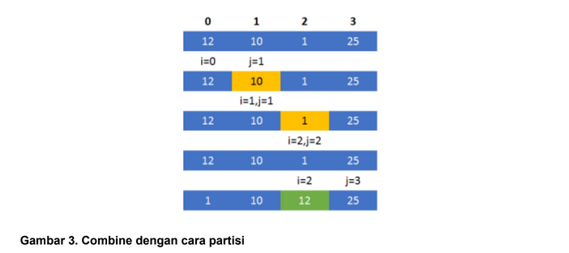

Gambar 3 tersebut menunjukkan partisi kembali data-data sebelum nilai pivot = 37. Proses partisi yang kedua ini menghasilkan nilai pivot baru yaitu 12, dimana data ini berada pada indeks ke-2. Akhir dari kedua partisi yang telah dilakukan, dimana telah dihasilkan nilai pivot 37 dengan indeks ke-4, serta nilai pivot 12 dengan indeks ke-2, menunjukkan bahwa, ketika data terurut, nilai 37 dan nilai 12 memang menempati posisi indeks ke-4 dan ke-2, seperti yang ditunjukkan pada Gambar 4.

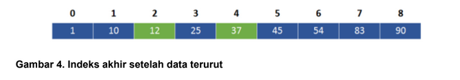

```python
def Quicksort(A,p,q):
    if p<q:
        r=partition(A,p,q)
        Quicksort(A, p, r-1)
        Quicksort(A, r+1, q)
```

```python
a=[37,83,10,1,45,25,12,90,54]
Quicksort(a,0,len(a)-1)
```

```
[37, 83, 10, 1, 45, 25, 12, 90, 54]
[37, 10, 83, 1, 45, 25, 12, 90, 54]
[37, 10, 1, 83, 45, 25, 12, 90, 54]
[37, 10, 1, 83, 45, 25, 12, 90, 54]
[37, 10, 1, 25, 45, 83, 12, 90, 54]
[37, 10, 1, 25, 12, 83, 45, 90, 54]
[37, 10, 1, 25, 12, 83, 45, 90, 54]
[37, 10, 1, 25, 12, 83, 45, 90, 54]
[12, 10, 1, 25, 37, 83, 45, 90, 54]
[12, 10, 1, 25, 37, 83, 45, 90, 54]
[12, 10, 1, 25, 37, 83, 45, 90, 54]
[1, 10, 12, 25, 37, 83, 45, 90, 54]
[1, 10, 12, 25, 37, 83, 45, 90, 54]
[1, 10, 12, 25, 37, 83, 45, 90, 54]
[1, 10, 12, 25, 37, 83, 45, 54, 90]
[1, 10, 12, 25, 37, 54, 45, 83, 90]
```

# Counting Sort

Algoritma sorting yang ketiga adalah algoritma sorting yang memiliki waktu komputasi lebih rendah dibandingkan kedua algoritma sebelumnya (merge sort dan quick sort), yaitu counting sort. Pada algoritma ini, masing-masing data yang akan diurutkan, dihitung jumlahnya terlebih dahulu. Sehingga ketika jumlah masing-masing data telah diketahui, maka data-data ini akan mudah ditempatkan ke dalam indeks masing-masing. Misalkan terdapat data [4, 3, 1, 2, 4, 2, 1, 1], maka akan dilakukan terlebih dahulu, perhitungan jumlah masing-masing data, yaitu : data-'1' berjumlah tiga data, sehingga akan menempati posisi indeks ke-0 sampai dengan indeks ke-2 data-'2' berjumlah dua buah data, sehingga akan menempati indeks ke-3 sampai dengan ke-4. data-'3' berjumlah satu buah data, sehingga hanya akan menempati indeks ke-5, sedangkan data-'4' berjumlah dua buah data, dan kedua data ini akan menempati indeks ke-6 dan ke-7.

### Code

Berikut adalah code untuk algoritma counting sort. Loop pertama untuk menyiapkan variabel yang berfungsi menyimpan jumlah komulatif dari masing-masing data, sehingga dengan nilai komulatif ini, maka masing-masing data dapat diletakkan pada indeks-indeks yang tepat berdasarkan nilai komulatif ini. Loop kedua digunakan untuk menghitung jumlah elemen pada masing-masing data. Misalkan pada contoh sebelumnya, data '1' berjumlah tiga buah elemen. Dari loop kedua ini, dilakukan perhitungan komulatif dari masing-masing data. Loop terakhir akan data akan ditempatkan sesuai dengan nilai komulatif tersebut.

```python
def countingSort(A,k):
    C=[]
    B=[]
    for i in range(k+1):
        C.append(0)
    for j in range(len(A)):
        C[A[j]]=C[A[j]]+1
        B.append(0)
    for i in range(1,k+1):
        C[i]=C[i]+C[i-1]
    for j in range(len(A)-1,-1,-1):
        B[C[A[j]]-1]=A[j]
        C[A[j]]=C[A[j]]-1
    return(B)
```

```python
a_list = [54, 26, 93, 17, 1, 31, 2, 55, 20,93,20,3,4,5]
countingSort(a_list,93)
```

```
[1, 2, 3, 4, 5, 17, 20, 20, 26, 31, 54, 55, 93, 93]
```

# Tugas Sorting

```python
import time
import random
import sys

sys.setrecursionlimit(2000)

def BubbleSort(arr):
    n = len(arr)
    for i in range(n):
        for j in range(0, n-i-1):
            if arr[j] > arr[j+1]:
                arr[j], arr[j+1] = arr[j+1], arr[j]

def SelectionSort(arr):
    n = len(arr)
    for i in range(n):
        min_idx = i
        for j in range(i+1, n):
            if arr[min_idx] > arr[j]:
                min_idx = j
        arr[i], arr[min_idx] = arr[min_idx], arr[i]

def InsertionSort(arr):
    for i in range(1, len(arr)):
        key = arr[i]
        j = i-1
        while j >= 0 and key < arr[j]:
            arr[j+1] = arr[j]
            j -= 1
        arr[j+1] = key

def MergeSort(arr):
    if len(arr) > 1:
        mid = len(arr) // 2
        L = arr[:mid]
        R = arr[mid:]
        MergeSort(L)
        MergeSort(R)
        i = j = k = 0
        while i < len(L) and j < len(R):
            if L[i] < R[j]:
                arr[k] = L[i]
                i += 1
            else:
                arr[k] = R[j]
                j += 1
            k += 1
        while i < len(L):
            arr[k] = L[i]
            i += 1
            k += 1
        while j < len(R):
            arr[k] = R[j]
            j += 1
            k += 1

def QuickSort(arr):
    if len(arr) <= 1:
        return arr
    pivot = arr[len(arr) // 2]
    left = [x for x in arr if x < pivot]
    middle = [x for x in arr if x == pivot]
    right = [x for x in arr if x > pivot]
    return QuickSort(left) + middle + QuickSort(right)

def hitung_waktu_sorting(jumlah_data):
    print(f"\n--- MENGUJI KECEPATAN UNTUK {jumlah_data} DATA ---")

    # Bikin data acak sebanyak jumlah_data
    data_acak = [random.randint(1, 1000) for _ in range(jumlah_data)]

    # Copy data agar semua algoritma mengurutkan set data yang sama
    arr_bubble = data_acak.copy()
    arr_selection = data_acak.copy()
    arr_insertion = data_acak.copy()
    arr_merge = data_acak.copy()
    arr_quick = data_acak.copy()

    # 1. Bubble Sort
    mulai = time.time()
    BubbleSort(arr_bubble)
    print(f"Bubble Sort    : {time.time() - mulai:.6f} detik")

    # 2. Selection Sort
    mulai = time.time()
    SelectionSort(arr_selection)
    print(f"Selection Sort : {time.time() - mulai:.6f} detik")

    # 3. Insertion Sort
    mulai = time.time()
    InsertionSort(arr_insertion)
    print(f"Insertion Sort : {time.time() - mulai:.6f} detik")

    # 4. Merge Sort
    mulai = time.time()
    MergeSort(arr_merge)
    print(f"Merge Sort     : {time.time() - mulai:.6f} detik")

    # 5. Quick Sort
    mulai = time.time()
    QuickSort(arr_quick)
    print(f"Quick Sort     : {time.time() - mulai:.6f} detik")

hitung_waktu_sorting(100)
hitung_waktu_sorting(500)
```

```
--- MENGUJI KECEPATAN UNTUK 100 DATA ---
Bubble Sort    : 0.000464 detik
Selection Sort : 0.000360 detik
Insertion Sort : 0.000272 detik
Merge Sort     : 0.000135 detik
Quick Sort     : 0.000335 detik

--- MENGUJI KECEPATAN UNTUK 500 DATA ---
Bubble Sort    : 0.010694 detik
Selection Sort : 0.009703 detik
Insertion Sort : 0.005757 detik
Merge Sort     : 0.001193 detik
Quick Sort     : 0.001500 detik
```